# Entregable 3 - Gabriela Eliana Rollano Málaga

2022-06-20

```r
library(rio)
library(DescTools)
library(ggplot2)
library(moments)
library(Rmisc)
library(e1071)
library(psych)
library(dplyr)
library(gplots)
library(vcd)
library(PMCMRplus)
library(nortest)
library(car)
library(stargazer)
library(lm.beta)
library(gtools)
library(jtools)
library(ggstance)
library(fastDummies)
library(writexl)
library(lmtest)
library(polycor)
library(ggcorrplot)
library(matrixcalc)
library(GPArotation)
library(lavaan)
library(BBmisc)
vdem = import("https://github.com/GabrielaRollano/Entregable-3/blob/main/V-Dem-CY-Core-v12.rds?raw=true")
View(vdem)
```

#1. Variable dependiente - Índice de Democracia Liberal (v2x_libdem)

```r
summary(vdem$v2x_libdem)
```

```
##    Min. 1st Qu.  Median    Mean 3rd Qu.    Max.    NA's
##  0.0050  0.0580  0.1250  0.2209  0.2920  0.8960    2619
```

```r
str(vdem$v2x_libdem)
```

```
##  num [1:27380] 0.04 0.04 0.04 0.04 0.04 0.04 0.04 0.04 0.04 0.04 ...
```

#2. Variables independientes - Gabriela Rollano #2.1.Autonomía de los Organismos Electorales (v2elembaut_ord)

```r
str(vdem$v2elembaut_ord)
```

```
##  num [1:27380] 0 0 0 0 0 0 0 0 0 0 ...
```

```r
summary(vdem$v2elembaut_ord)
```

```
##    Min. 1st Qu.  Median    Mean 3rd Qu.    Max.    NA's
##   0.000   0.000   0.000   1.227   3.000   4.000    3016
```

#2.2 Medios de comunicación escritos o transmitidos críticos del gobierno (v2mecrit_ord)

```r
str(vdem$v2mecrit_ord)
```

```
##  num [1:27380] 1 1 1 1 1 1 1 1 1 1 ...
```

```r
summary(vdem$v2mecrit_ord)
```

```
##    Min. 1st Qu.  Median    Mean 3rd Qu.    Max.    NA's
##   0.000   1.000   1.000   1.397   2.000   3.000     873
```

#2.3. Respeto a Contraargumentos (v2dlcountr_ord)

```r
str(vdem$v2dlcountr_ord)
```

```
##  num [1:27380] NA NA NA NA NA NA NA NA NA NA ...
```

```r
summary(vdem$v2dlcountr_ord)
```

```
##    Min. 1st Qu.  Median    Mean 3rd Qu.    Max.    NA's
##     0.0     1.0     2.0     1.6     2.0     5.0    8370
```

#3. Variables independientes #3.1. Organizaciones de Sociedad civil #3.1.1. Represión gubernamental de Organizaciones de Sociedad Civil (v2csreprss_ord)

```r
str(vdem$v2csreprss_ord)
```

```
##  num [1:27380] 1 1 1 1 1 1 1 1 1 1 ...
```

```r
summary(vdem$v2csreprss_ord)
```

```
##    Min. 1st Qu.  Median    Mean 3rd Qu.    Max.    NA's
##    0.00    1.00    2.00    2.07    3.00    4.00     749
```

#3.1.2. Control gubernamental sobre Organizaciones de Sociedad Civil (v2cseeorgs_ord)

```r
str(vdem$v2cseeorgs_ord)
```

```
##  num [1:27380] 0 0 0 0 0 0 0 0 0 0 ...
```

```r
summary(vdem$v2cseeorgs_ord)
```

```
##    Min. 1st Qu.  Median    Mean 3rd Qu.    Max.    NA's
##   0.000   0.000   1.000   1.597   3.000   4.000     580
```

#3.1.3. Consulta gubernamental hacia Organizaciones de Sociedad Civil (v2cscnsult_ord)

```r
str(vdem$v2cscnsult_ord)
```

```
##  num [1:27380] 0 0 0 0 0 0 0 0 0 0 ...
```

```r
summary(vdem$v2cscnsult_ord)
```

```
##    Min. 1st Qu.  Median    Mean 3rd Qu.    Max.    NA's
##  0.0000  0.0000  0.0000  0.4807  1.0000  2.0000     554
```

# Armar la base de apoyo

```r
cluster_gabriela = subset(vdem, select = c(country_name, year, v2x_libdem, v2elembaut_ord, v2mecrit_ord, v2dlcountr_ord, v2csreprss_ord, v2cseeorgs_ord, v2cscnsult_ord))
```

```r
cluster_gabriela = cluster_gabriela[cluster_gabriela$year==2021,]
```

```r
# Trabajaremos con los nombres de los países y las seis variables independientes escogidas, por eso anulamos el año y la variable dependiente.
cluster_gabriela$year = NULL
cluster_gabriela$v2x_libdem = NULL
```

```r
str(cluster_gabriela)
```

```
## 'data.frame':    179 obs. of  7 variables:
##  $ country_name  : chr  "Mexico" "Suriname" "Sweden" "Switzerland" ...
##  $ v2elembaut_ord: num  4 3 4 4 3 3 3 0 0 2 ...
##  $ v2mecrit_ord  : num  2 3 3 3 2 3 3 0 1 2 ...
##  $ v2dlcountr_ord: num  2 2 4 4 2 3 4 1 1 2 ...
##  $ v2csreprss_ord: num  3 4 4 4 4 3 4 1 1 4 ...
##  $ v2cseeorgs_ord: num  3 4 4 4 4 4 4 0 1 3 ...
##  $ v2cscnsult_ord: num  0 1 2 2 2 1 1 0 0 1 ...
```

# Hacemos la estandarización.

```r
library(BBmisc)
cluster_gabriela[,-1]=normalize(cluster_gabriela[,-1],method='standardize')
cluster_gabriela=cluster_gabriela[complete.cases(cluster_gabriela),]
```

```r
summary(cluster_gabriela)
```

```
##  country_name       v2elembaut_ord     v2mecrit_ord      v2dlcountr_ord
##  Length:179         Min.   :-1.5482   Min.   :-2.34382   Min.   :-1.9144
##  Class :character   1st Qu.:-0.8571   1st Qu.:-0.04495   1st Qu.:-0.1156
##  Mode  :character   Median : 0.5251   Median :-0.04495   Median :-0.1156
##                     Mean   : 0.0000   Mean   : 0.00000   Mean   : 0.0000
##                     3rd Qu.: 0.5251   3rd Qu.: 1.10448   3rd Qu.: 0.7838
##                     Max.   : 1.2162   Max.   : 1.10448   Max.   : 2.5826
##  v2csreprss_ord    v2cseeorgs_ord    v2cscnsult_ord
##  Min.   :-2.2807   Min.   :-2.0256   Min.   :-1.45913
##  1st Qu.:-0.6445   1st Qu.:-0.8459   1st Qu.: 0.03335
##  Median : 0.1737   Median : 0.3339   Median : 0.03335
##  Mean   : 0.0000   Mean   : 0.0000   Mean   : 0.00000
##  3rd Qu.: 0.9918   3rd Qu.: 1.1205   3rd Qu.: 0.03335
##  Max.   : 0.9918   Max.   : 1.1205   Max.   : 1.52583
```

# Vemos las correlaciones.

```r
cor(cluster_gabriela[,-1])
```

```
##                v2elembaut_ord v2mecrit_ord v2dlcountr_ord v2csreprss_ord
## v2elembaut_ord      1.0000000    0.7377899      0.6826106      0.7945379
## v2mecrit_ord        0.7377899    1.0000000      0.6917230      0.7422000
## v2dlcountr_ord      0.6826106    0.6917230      1.0000000      0.7146772
## v2csreprss_ord      0.7945379    0.7422000      0.7146772      1.0000000
## v2cseeorgs_ord      0.7581324    0.7667901      0.6945539      0.8888291
## v2cscnsult_ord      0.6429916    0.6375932      0.6675044      0.7144543
##                v2cseeorgs_ord v2cscnsult_ord
## v2elembaut_ord      0.7581324      0.6429916
## v2mecrit_ord        0.7667901      0.6375932
## v2dlcountr_ord      0.6945539      0.6675044
## v2csreprss_ord      0.8888291      0.7144543
## v2cseeorgs_ord      1.0000000      0.6812573
## v2cscnsult_ord      0.6812573      1.0000000
```

```r
dataClus=cluster_gabriela[,-1]
row.names(dataClus)=cluster_gabriela$country_name
```

```r
library(cluster)
g.dist = daisy(dataClus, metric="gower")
```

# Para ver el número ideal de clusters dependiendo del método, la idea es disminuir dimensiones, si tenemos 10 grupos no se reduciría como si tuviéramos 4 por ejemplo.

# En primer lugar para hacer el cálculo de cuantos grupos o cuantos conglomerados se van a constituir recurrí a la medida gap y especifique el método que voy a utilizar y por cada método nos da un número de clusters y a partir de ese número de clusters sugerido por PAM, AGNES Y DIANA, es que los ejecuté y luego se hace la visualización que permite ver cuántos casos están mal agrupado y están quedando fuera de una agrupación correcta. El que mejor agrupa es AGNES.

# PAM

```r
# El número sugerido de clusters, específicamente para la estrategia particionante es 9.
library(factoextra)
```

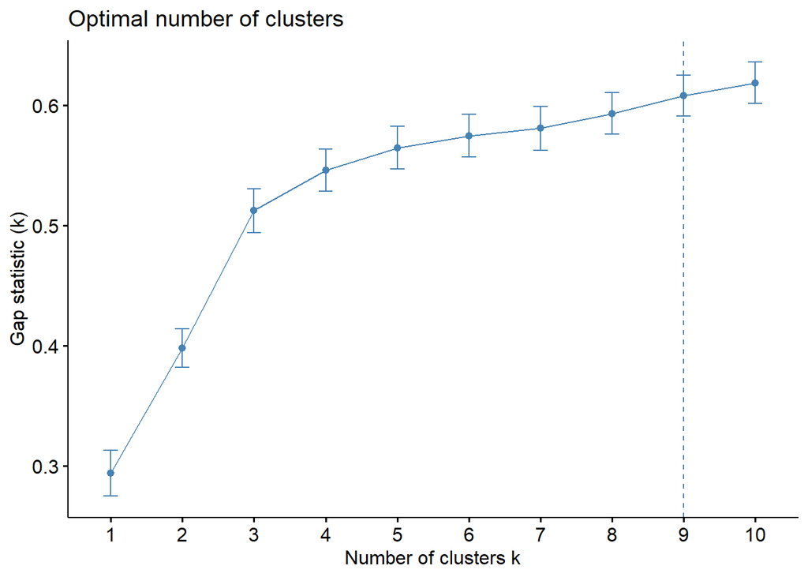

```r
set.seed(123)
fviz_nbclust(dataClus,
             pam,
             diss=g.dist,
             method = "gap_stat",
             k.max = 10,
             verbose = F)
```

# AGNES

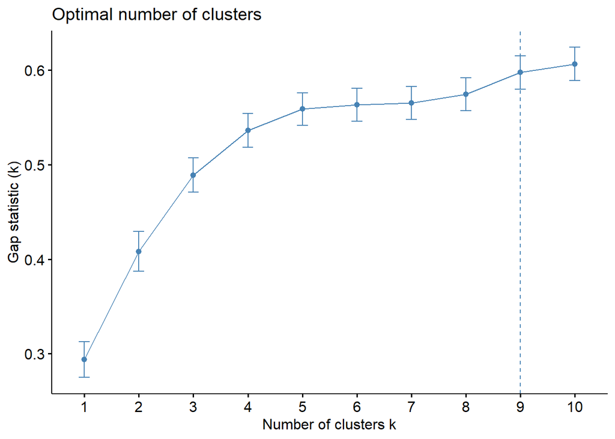

```r
# El número sugerido de clusters, específicamente para la estrategia AGNES es 9
set.seed(123)
fviz_nbclust(dataClus,
             hcut,
             diss = g.dist,
             method = "gap_stat",
             k.max = 10,
             verbose = F,
             hc_func = "agnes")
```

# DIANA

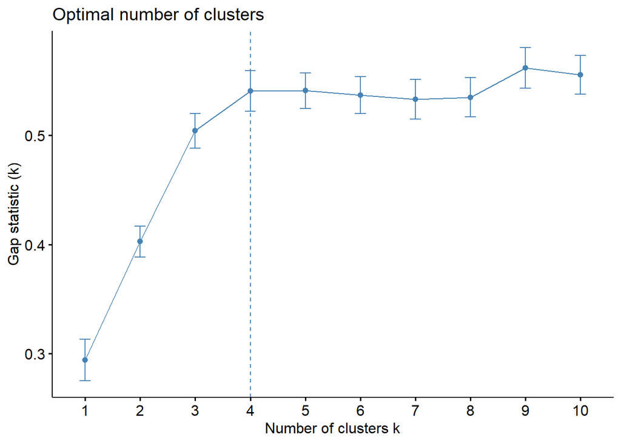

```r
# El número sugerido de clusters, específicamente para la estrategia divisiva es 4.
set.seed(123)
fviz_nbclust(dataClus, hcut,diss=g.dist,method = "gap_stat",k.max = 10,verbose = F,hc_func = "diana")
```

#Evaluar resultados, para saber cuál es la estrategia que más nos conviene.

```r
###pam
set.seed(123)

res.pam=pam(g.dist,k = 9,cluster.only = F)

###agnes
res.agnes<- hcut(g.dist, k = 9,hc_func='agnes',hc_method = "ward.D")

### diana
res.diana <- hcut(g.dist, k = 4,hc_func='diana')
```

# Se escoge el que menos casos abajo porque tienen mal ajuste. Vemos que DIANA tiene más casos abajo

```
##   cluster size ave.sil.width
## 1       1   41          0.29
## 2       2   18          0.40
## 3       3   37          0.53
## 4       4   18          0.31
## 5       5   13          0.49
## 6       6   21          0.17
## 7       7   10          0.17
## 8       8   14          0.29
## 9       9    7          0.31
```

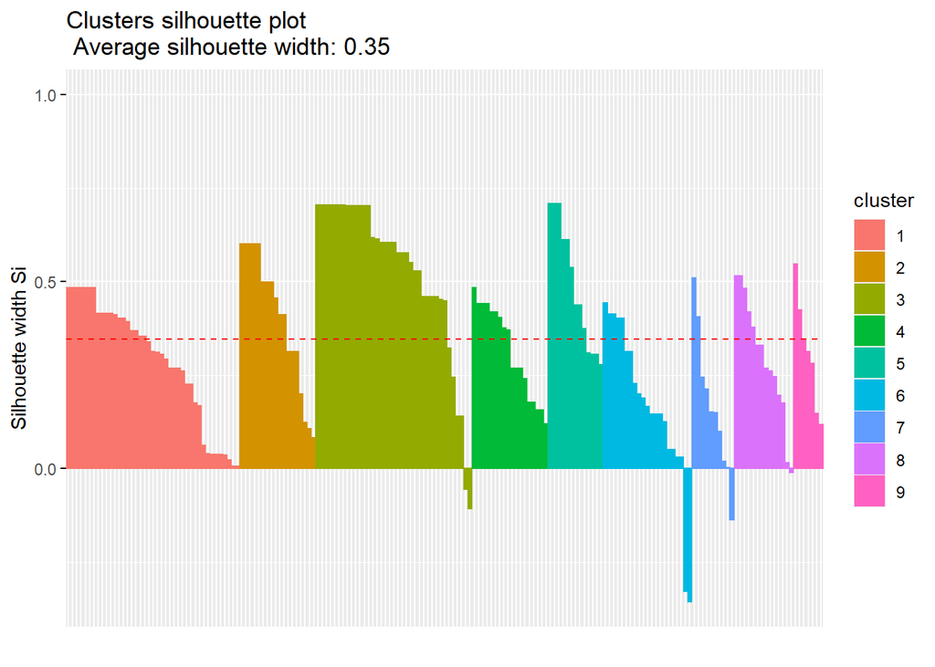

```r
fviz_silhouette(res.pam)
```

```
##   cluster size ave.sil.width
## 1       1   47          0.33
## 2       2   24          0.32
## 3       3   38          0.53
## 4       4   16          0.33
## 5       5   16          0.35
## 6       6    8          0.29
## 7       7    7          0.61
## 8       8   14          0.17
## 9       9    9          0.36
```

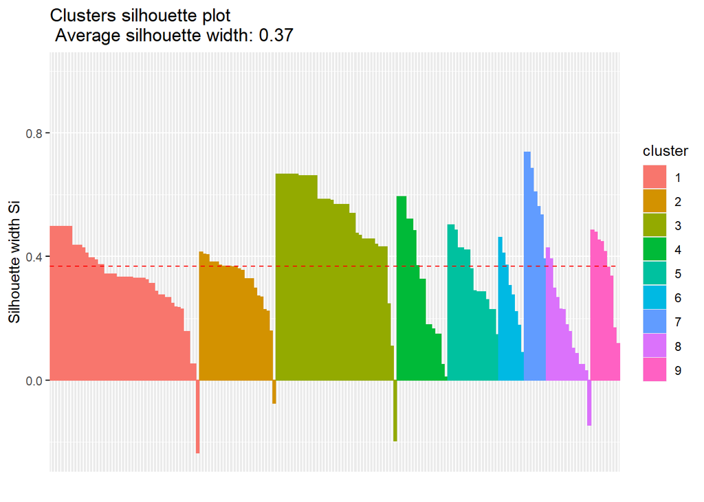

```r
fviz_silhouette(res.agnes)
```

```
##   cluster size ave.sil.width
## 1       1    6          0.37
## 2       2  116          0.26
## 3       3   36          0.45
## 4       4   21          0.30
```

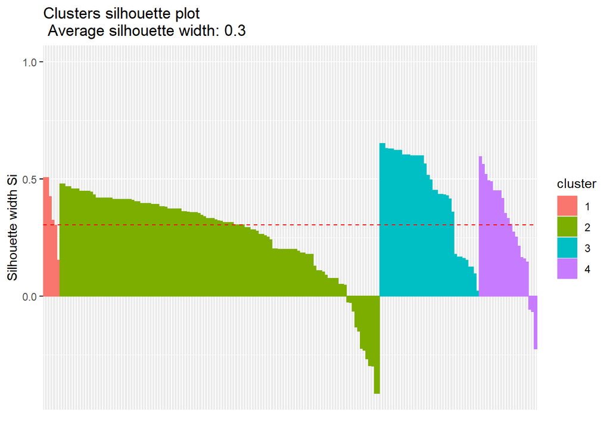

```r
fviz_silhouette(res.diana)
```

# A partir del gráfico de siluetas, se tiene que el número sugerido para la técnica jerárquica aglomerativa es el que mayor puntuación genera, por lo tanto, es el que menos casos malagrupa.

#Estrategia aglomerativa

```r
set.seed(123)
res.agnes <- hcut(g.dist, k = 9,hc_func='agnes',hc_method = "ward.D")
dataClus$agnes=res.agnes$cluster
```

# Es normal que salgan valores negativos porque está estandarizado, se está pidiendo la media de cada grupo por variable.

```r
aggregate(.~ agnes, data=dataClus, mean)
```

```
##   agnes v2elembaut_ord v2mecrit_ord v2dlcountr_ord v2csreprss_ord
## 1     1      0.4662717  -0.06940595      0.1140691      0.4696023
## 2     2      0.5826822   1.10448366      0.4465614      0.5827484
## 3     3      0.9433934   0.89274590      1.0205228      0.9487552
## 4     4     -1.5482422  -2.05645867     -1.5770964     -1.6671174
## 5     5     -1.2026869  -0.90702510     -1.0149693     -1.4114508
## 6     6     -0.2524098   0.24240848     -0.2279912     -0.3376513
## 7     7     -1.5482422  -0.04494992     -0.1155658     -0.2938227
## 8     8     -0.2647511  -0.04494992     -0.3082951     -0.5860131
## 9     9     -1.2410819  -1.19438349     -0.7151681     -1.0989695
##   v2cseeorgs_ord v2cscnsult_ord
## 1      0.5180281    -0.03015823
## 2      0.6288955    -0.02883511
## 3      0.8307029     1.52582886
## 4     -1.7798567    -1.36584612
## 5     -1.4357493    -1.45912596
## 6     -0.2559522    -1.45912596
## 7      0.3339463     0.03335145
## 8     -0.6773083     0.03335145
## 9     -1.1517241     0.03335145
```

# Se reagrupa y se trata de identificar los grupos mejor posicionados.

```r
dataClus$agnes=dplyr::recode(dataClus$agnes, `3` = 1,
                             `2`=2,
                             `1`=3,
                             `6`=4,
                             `8`=5,
                             `5`=6,
                             `9`=7,
                             `7`=8,
                             `4`=9)
```

# Proyección de dendograma.

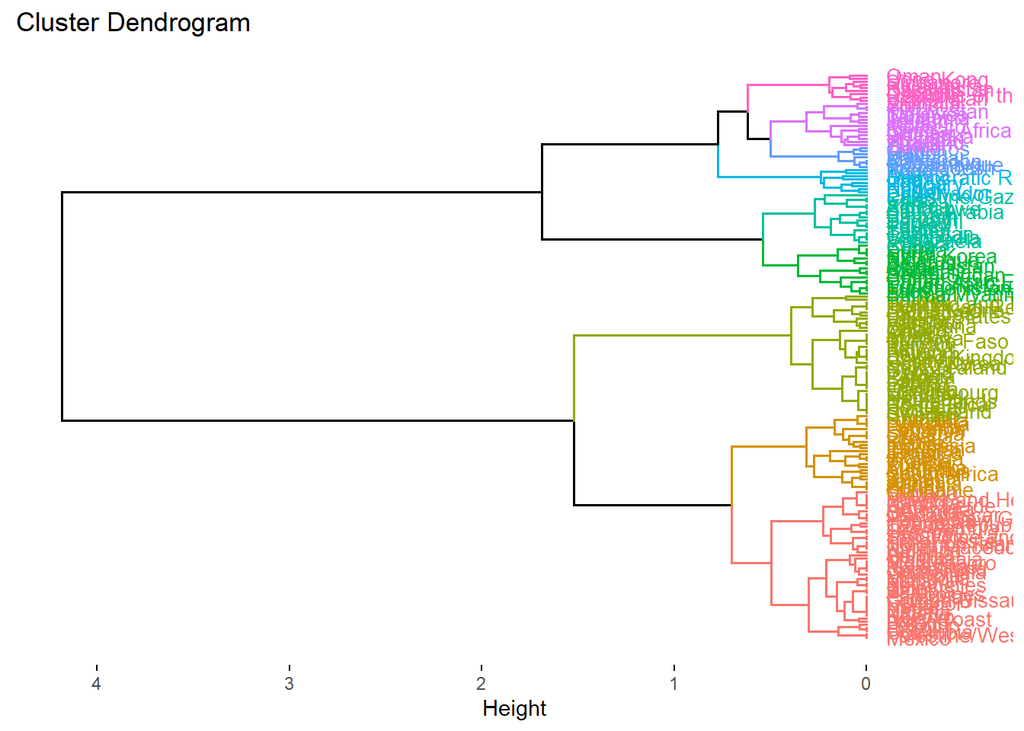

```r
fviz_dend(res.agnes, cex = 0.7, horiz = T)
```

#Estrategia basada en densidad # Como nos interesa clusterizar todos los casos no vamos a usar la estrategia basada en densidad, esta es buena estrategia cuando hay escenarios en los que tenga que excluir los casos y no me conviene dejar fuera 11 cuando con la estrategia AGNES tengo la posibilidad de mal agrupar sólo a 4.

```r
proyeccion = cmdscale(g.dist, k=2 , add = T)
```

```r
dataClus$dim1 <- proyeccion$points[,1]
dataClus$dim2 <- proyeccion$points[,2]
```

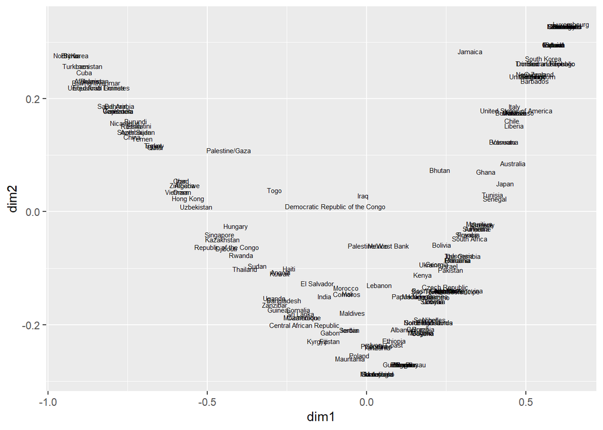

```r
base= ggplot(dataClus,aes(x=dim1, y=dim2,label=row.names(dataClus)))
base + geom_text(size=2)
```

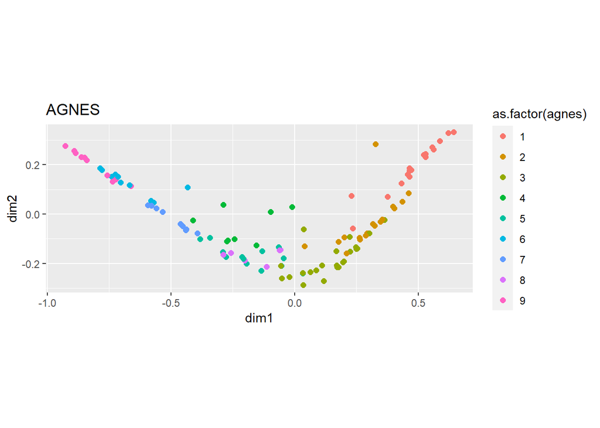

```r
base= ggplot(dataClus,aes(x=dim1, y=dim2)) +  coord_fixed()
base + geom_point(size=2, aes(color=as.factor(agnes))) + labs(title = "AGNES")
```

```r
g.dist.cmd = daisy(dataClus[,c('dim1','dim2')], metric = 'euclidean')
```